# 🎯 Objetivos

Este archivo realiza un Análisis Exploratorio de Datos (EDA) completo sobre los juegos ya filtrados. El **objetivo** es comprender la estructura, los sesgos y calidad de los datos antes de pasar a la creación de los embeddings y la construcción de los modelos de recomendación.

- ⚙️ **Configuración inicial**. Rutas, paquetes y funciones.
- ♻️ **Carga de datos**.
- ➕ **Variables derivadas**. Release_date y variables intermedias.
- **Análisis** de la calidad de los datos:
  - 📚 **Descripción general**. Información de la tabla en su conjunto.
  - 🔢 **Variables numéricas**.
  - 🏷️ **Variables categóricas**.
  - 🔘 **Variables booleanas**.
  - 🎭 **Variables de género del videojuego**.
  - 📜 **Variabels de texto**.
- 💾 **Guardado de información**. Guardado de información y resumen de los datos almacenados.

# ⚙️ Configuración inicial

## Rutas (paths)

```python
import os

# Rutas en función de la carpeta raíz del proyecto (README.md)
base_path = os.path.dirname(os.path.dirname(os.path.abspath(__file__))) if "__file__" in locals() else os.path.abspath("..")

# Subrutas
data_dir = os.path.join(base_path, "data")
db_path = os.path.join(data_dir, "steam.db")
src_dir = os.path.join(base_path, "src")
```

## Paquetes y funciones

```python
# Configuración general
import warnings
warnings.filterwarnings("ignore")
import re
import sqlite3

# Análisis y manipulación de datos
import pandas as pd
import numpy as np

# Visualización
import matplotlib.pyplot as plt
import seaborn as sns
from wordcloud import WordCloud

# Procesamiento de lenguaje natural (NLP)
import spacy   # python -m spacy download en_core_web_md
from bs4 import BeautifulSoup
from langdetect import detect, DetectorFactory
import nltk
# nltk.download("stopwords")
from nltk.corpus import stopwords
stop_words = stopwords.words("english")

# Modelado de texto y machine learning
from sklearn.feature_extraction.text import CountVectorizer, TfidfVectorizer

# Reducción de dimensionalidad y clustering
from sklearn.cluster import AgglomerativeClustering
from sklearn.decomposition import PCA
```

# ♻️ Carga de datos

```python
# Cargamos
conn = sqlite3.connect(db_path)
cur = conn.cursor()

games = pd.read_sql("SELECT * FROM games_filtered", conn)

conn.close()

# Hacemos una copia para trabajar
games_eda = games.copy()
```

# ➕ Variables derivadas

- Crear la variable `release_year` (Esperado: >95% de los casos recuperados).
- Variables intermedias con el nombre de las columnas relevantes por tipo.

```python
# Creación de la variable release_year
games_eda["release_year"] = (
    games_eda["release_date"]
    .astype(str)
    .str.extract(r"(\d{4})")[0]   # Extrae el primer grupo de 4 números
    .astype(float)
)

# Número de casos convertidos
valid_release_year = games_eda["release_year"].notna().mean() * 100
print(f"Fechas convertidas: {valid_release_year:.1f}%")

# Comprobamos los que hemos dejado sin convertir
invalid_release_year = games_eda.loc[games_eda["release_year"].isna(), "release_date"].unique()
print(f"\nCasos no convertidos:\n{invalid_release_year}")
```

```
Fechas convertidas: 97.0%

Casos no convertidos:
['' None]
```

```python
# Variables numéricas
num_cols = ["score_reviews", "release_year"]

# Variables categóricas / textuales
cat_cols = ["developers","publishers"]

# Variables texto
text_cols = ["description","content_descriptors_notes"]

# Variables booleanas (excepto género)
bool_cols = ["windows", "mac", "linux","multijugador", "cooperativo", "competitivo", "multidispositivo", "free"]

# Variables género
genre_cols = [col for col in games_eda.columns if col.startswith("genre_")]
```

# 📚 Descripción general

Lo primero es obtener una visión general de la estructura de los datos de la tabla games_eda asi como de su calidad (nulos, duplicados, etc). El **objetivo** es verificar que la información disponible es coherente y completa antes de pasar al modelado y el sistema de recomendación.

```python
# Dimensiones de la tabla
n_filas, n_columnas = games_eda.shape
print(f"La tabla presenta {n_filas:,} filas y {n_columnas} columnas\n")
```

```
La tabla presenta 2,576 filas y 54 columnas
```

```python
# Nulos por columnas

null_counts = games_eda.isna().sum()          # Número de nulos
null_percent = (null_counts / n_filas) * 100  # Porcentaje de nulos

# Pasamos a f
null_summary = pd.DataFrame({
    "Nulos (#)": null_counts,
    "Nulos (%)": null_percent.round(2)
}).sort_values("Nulos (%)", ascending=False)

# Resultados
print("Cantidad y % de nulos por columna:\n")
print(null_summary.to_string())
```

```
Cantidad y % de nulos por columna:

                           Nulos (#)  Nulos (%)
median_forever                  2576     100.00
average_forever                 2576     100.00
content_descriptors_notes       1953      75.82
release_year                      76       2.95
free                              71       2.76
description                       71       2.76
linux                             71       2.76
release_date                      71       2.76
multijugador                      71       2.76
cooperativo                       71       2.76
competitivo                       71       2.76
windows                           71       2.76
mac                               71       2.76
developers                        71       2.76
genre_action                      71       2.76
multidispositivo                  71       2.76
genre_sports                      71       2.76
genre_mmo                         71       2.76
genre_indie                       71       2.76
genre_adventure                   71       2.76
genre_strategy                    71       2.76
publishers                        71       2.76
genre_utilities                   71       2.76
genre_video                       71       2.76
genre_dev                         71       2.76
genre_web                         71       2.76
genre_sexual                      71       2.76
genre_rpg                         71       2.76
genre_free                        71       2.76
genre_simulation                  71       2.76
genre_accounting                  71       2.76
genre_animation                   71       2.76
genre_audio                       71       2.76
genre_design                      71       2.76
genre_education                   71       2.76
genre_photo                       71       2.76
genre_training                    71       2.76
genre_casual                      71       2.76
genre_gore                        71       2.76
genre_movie                       71       2.76
genre_eposodic                    71       2.76
genre_doc                         71       2.76
genre_short                       71       2.76
genre_nudity                      71       2.76
genre_violent                     71       2.76
genre_early                       71       2.76
genre_360                         71       2.76
genre_tutorial                    71       2.76
genre_racing                      71       2.76
name                               0       0.00
score_reviews                      0       0.00
positive_reviews                   0       0.00
total_reviews                      0       0.00
appid                              0       0.00
```

```python
# Nulos por fila

null_filas = games_eda.isna().sum(axis=1)                           # Cantidad nulos
tabla_nulos = null_filas.value_counts().sort_index().reset_index()  # Agrupar
tabla_nulos.columns = ["Nulos por juego", "Número de juegos"]       # Renombrar columnas

# Resultados
print("Cantidad de juegos que pierden información:\n")
print(tabla_nulos.to_string(index=False))
```

```
Cantidad de juegos que pierden información:

 Nulos por juego  Número de juegos
               2               623
               3              1877
               4                 5
              49                71
```

```python
# Resultado 3 columnas nulas
null_3 = (
    games_eda[games_eda.isna().sum(axis=1) == 3]           # Filtrar filas con 3 nulos
    .apply(lambda x: ", ".join(x.index[x.isna()]), axis=1) # Extraer nombres de columnas nulas
    .value_counts()                                        # Contar combinaciones
    .reset_index(name="Número de filas")                   # Formatear resultado
    .rename(columns={"index": "Columnas_nulas"})           # Renombrar columna
)

print(f"Filas con 3 nulos:")
print(null_3.to_string(index=False))

# Resultado 4 columnas nulas
null_4 = (
    games_eda[games_eda.isna().sum(axis=1) == 4]           # Filtrar filas con 4 nulos
    .apply(lambda x: ", ".join(x.index[x.isna()]), axis=1) # Extraer nombres de columnas nulas
    .value_counts()                                        # Contar combinaciones
    .reset_index(name="Número de filas")                   # Formatear resultado
    .rename(columns={"index": "Columnas_nulas"})           # Renombrar columna
)

print(f"\nFilas con 4 nulos:")
print(null_4.to_string(index=False))
```

```
Filas con 3 nulos:
                                            Columnas_nulas  Número de filas
average_forever, median_forever, content_descriptors_notes             1877

Filas con 4 nulos:
                                                          Columnas_nulas  Número de filas
average_forever, median_forever, content_descriptors_notes, release_year                5
```

```python
# Duplicados
dup_name  = games_eda["name"].duplicated().sum()
dup_appid = games_eda["appid"].duplicated().sum()
print(f"Tenemos {dup_name} duplicados por nombre y {dup_appid} duplicados por appid")
```

```
Tenemos 0 duplicados por nombre y 0 duplicados por appid
```

# 🔢 Análisis variables numéricas

En este bloque se estudia el comportamiento de las variables cuantitativas (distribución, rango y posibles relaciones entre ellas).

```python
# Descriptivos básicos
games_eda[["score_reviews", "release_year"]].describe()
```

|  | score_reviews | release_year |
| --- | --- | --- |
| count | 2576.000000 | 2500.000000 |
| mean | 0.846114 | 2018.788800 |
| std | 0.116091 | 4.477702 |
| min | 0.159892 | 1997.000000 |
| 25% | 0.792361 | 2016.000000 |
| 50% | 0.877086 | 2019.000000 |
| 75% | 0.931952 | 2022.000000 |
| max | 0.994096 | 2025.000000 |

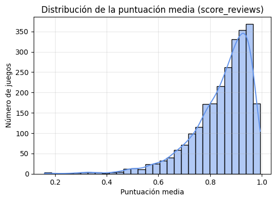

```python
# score_reviews
plt.figure(figsize=(6,4))
sns.histplot(games_eda["score_reviews"], bins=30, kde=True, color="cornflowerblue")
plt.title("Distribución de la puntuación media (score_reviews)")
plt.xlabel("Puntuación media")
plt.ylabel("Número de juegos")
plt.grid(alpha=0.3)
plt.show()
```

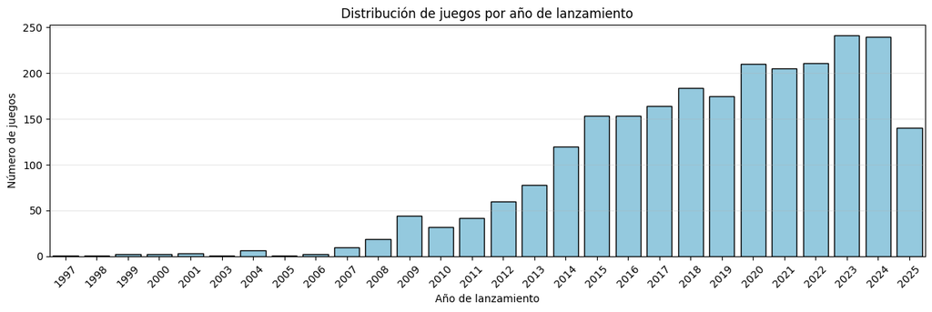

```python
# Release year
plt.figure(figsize=(15,4))
sns.countplot(data=games_eda, x="release_year", color="skyblue", edgecolor="black")
plt.title("Distribución de juegos por año de lanzamiento")
plt.xlabel("Año de lanzamiento")
plt.ylabel("Número de juegos")
years = sorted(games_eda["release_year"].dropna().unique().astype(int))
plt.xticks(ticks=range(len(years)), labels=years, rotation=45)
plt.grid(axis="y", alpha=0.3)
plt.show()
```

```
Coeficiente de correlación (Pearson): 0.021
```

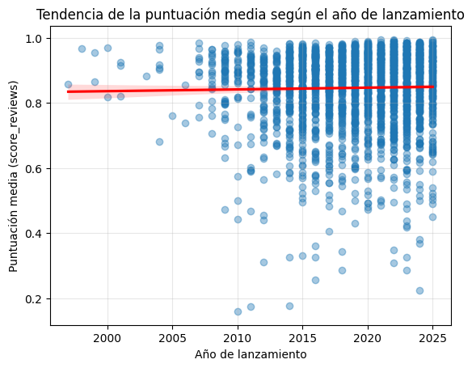

```python
# Correlación entre release_year y score_reviews
corr = games_eda["release_year"].corr(games_eda["score_reviews"])
print(f"Coeficiente de correlación (Pearson): {corr:.3f}")

sns.regplot(
    data=games_eda,
    x="release_year",
    y="score_reviews",
    scatter_kws={"alpha": 0.4},
    line_kws={"color": "red"}
)
plt.title("Tendencia de la puntuación media según el año de lanzamiento")
plt.xlabel("Año de lanzamiento")
plt.ylabel("Puntuación media (score_reviews)")
plt.grid(alpha=0.3)
plt.show()
```

# 🏷️ Análisis variables categóricas

En esta sección se analizan las variables categóricas con el objetivo de entender su distribución, cardinalidad y sus potenciales aportaciones al sistema de recomendación.

El modelo incluye las siguientes variables categóricas: `developers`y `publishers`.

```python
# Niveles developers
games_eda["developers"].value_counts()
```

```
developers
Square Enix                        25
Valve                              21
KOEI TECMO GAMES CO., LTD.         16
CAPCOM Co., Ltd.                   14
Ubisoft Montreal                   10
                                   ..
Rone Vine                           1
Trioskaz                            1
MogDogBlog Productions              1
Joeveno                             1
Rockstar North,Rockstar Toronto     1
Name: count, Length: 1898, dtype: int64
```

```python
# Niveles publisher
games_eda["publishers"].value_counts()
```

```
publishers
Square Enix               44
SEGA                      41
Electronic Arts           40
Ubisoft                   38
Devolver Digital          35
                          ..
Ludu Arts                  1
念念而忘(Indelible Studio)     1
Gamersky Games             1
Rone Vine                  1
滑稽工作室                      1
Name: count, Length: 1381, dtype: int64
```

```python
# Niveles de ambas variables juntas
games_eda[["developers","publishers"]].value_counts()
```

```
developers                                                     publishers
Square Enix                                                    Square Enix                   25
Valve                                                          Valve                         21
KOEI TECMO GAMES CO., LTD.                                     KOEI TECMO GAMES CO., LTD.    16
CAPCOM Co., Ltd.                                               CAPCOM Co., Ltd.              13
Ubisoft Montreal                                               Ubisoft                       10
                                                                                             ..
橘子班                                                            NVLMaker                       1
汉家松鼠Han-Squirrel Studio                                        XD                             1
游戏养家工作室                                                        游戏养家工作室                        1
滑稽工作室                                                          滑稽工作室                          1
2K Boston,2K Australia,Blind Squirrel,Feral Interactive (Mac)  2K,Feral Interactive (Mac)     1
Name: count, Length: 2034, dtype: int64
```

```python
# Número de juegos por cada developer
dev_count = games_eda["developers"].value_counts().reset_index()
dev_count.columns = ["developers", "num_games"]

# Recodificamos según el número de juegos publicados por cada estudio.
def categorize_developer(n):
    if n >= 10:
        return "large"
    elif n >= 3:
        return "medium"
    else:
        return "small"

dev_count["developer_level"] = dev_count["num_games"].apply(categorize_developer)

# Creamos la nueva columna
games_eda = games_eda.merge(
    dev_count[["developers", "developer_level"]],
    on="developers",
    how="left"
)

print("Distribución de juegos por publicaciones del estudio:")
print(games_eda["developer_level"].value_counts())
```

```
Distribución de juegos por publicaciones del estudio:
developer_level
small     1978
medium     441
large       86
Name: count, dtype: int64
```

```python
# Ejemplos de developers por cada nivel
grandes = games_eda.loc[games_eda["developer_level"] == "large", "developers"].unique()
medianos = games_eda.loc[games_eda["developer_level"] == "medium", "developers"].unique()
pequeños = games_eda.loc[games_eda["developer_level"] == "small", "developers"].unique()

print("Estudios grandes:", ", ".join(np.random.choice(grandes, 3, replace=False)))
print("Estudios medianos:", ", ".join(np.random.choice(medianos, 3, replace=False)))
print("Estudios pequeños:", ", ".join(np.random.choice(pequeños, 3, replace=False)))
```

```
Estudios grandes: Valve, CAPCOM Co., Ltd., Square Enix
Estudios medianos: Game-Labs, Streum On Studio, SEGA
Estudios pequeños: Table 9 Studio, Digital Tentacle, Trashmasters,Zoom Platform
```

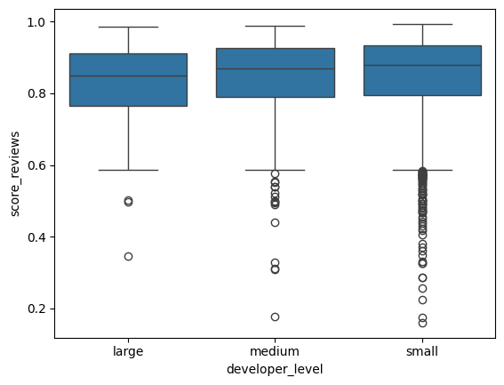

```python
# Distribuión score_review por cada developer_level
sns.boxplot(data=games_eda, x="developer_level", y="score_reviews")
```

# 🔘 Análisis variables booleanas

En este bloque se analizan las variables booleanas presentes en los datos que incluyen información sobre la disponibilidad de un juego en determinada plataforma, las modalidades de juego y algunas características adicionales.

```python
# Porcentaje de juegos que presentan una determinada característica
bool_summary = games_eda[bool_cols].mean().sort_values(ascending=False) * 100
print("Porcentaje de juegos que presentan cada característica:\n")
print(bool_summary.round(2))
```

```
Porcentaje de juegos que presentan cada característica:

windows             100.00
multijugador         36.53
mac                  32.69
cooperativo          23.71
linux                22.00
multidispositivo     19.92
competitivo          17.41
free                  1.60
dtype: float64
```

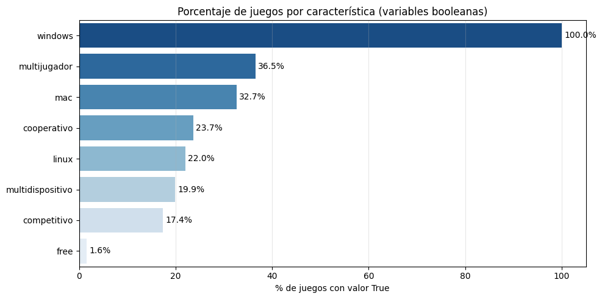

```python
plt.figure(figsize=(10, 5))
ax = sns.barplot(x=bool_summary.values, y=bool_summary.index, palette="Blues_r")

# Títulos y etiquetas
plt.title("Porcentaje de juegos por característica (variables booleanas)")
plt.xlabel("% de juegos con valor True")
plt.ylabel("")
plt.grid(axis="x", alpha=0.3)

# Porcentajes
for i, (value, label) in enumerate(zip(bool_summary.values, bool_summary.index)):
    ax.text(value + 0.5, i, f"{value:.1f}%", va="center")

plt.tight_layout()
plt.show()
```

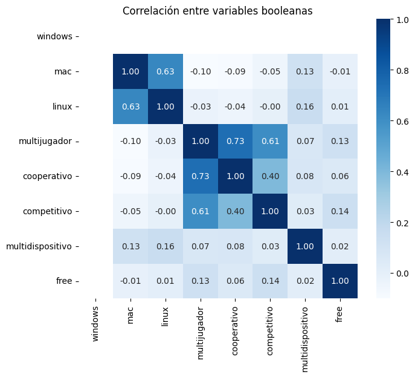

```python
# Correlación entre variables booleanas
corr_bool = games_eda[bool_cols].corr()

plt.figure(figsize=(8,6))
sns.heatmap(corr_bool, annot=True, cmap="Blues", fmt=".2f", square=True)
plt.title("Correlación entre variables booleanas")
plt.show()
```

# 🎭 Análisis variables género

El objetivo de este bloque es reducir la complejidad del espacio de géneros para obtener una representación más manejable. Para ello se adopta una doble aproximación: análisis de correlaciones y análisis de similaridad semántica.

```python
print(f"Número total de géneros: {len(genre_cols)}")
```

```
Número total de géneros: 33
```

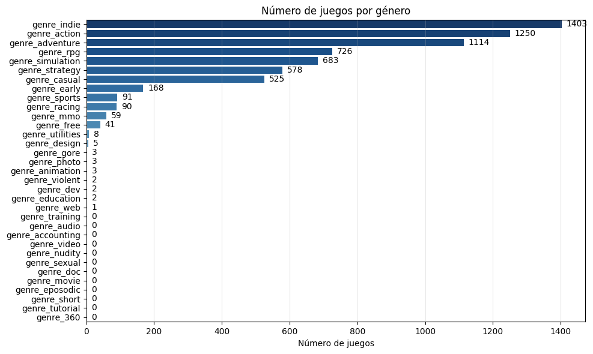

```python
# Frecuencia de cada género
genre_counts = games_eda[genre_cols].sum().sort_values(ascending=False)

plt.figure(figsize=(10, 6))
ax = sns.barplot(x=genre_counts.values, y=genre_counts.index, palette="Blues_r")

plt.title("Número de juegos por género")
plt.xlabel("Número de juegos")
plt.ylabel("")
plt.grid(axis="x", alpha=0.3)

# Valores
for i, (value, label) in enumerate(zip(genre_counts.values, genre_counts.index)):
    ax.text(value + max(genre_counts.values)*0.01, i, f"{int(value)}", va="center")

plt.tight_layout()
plt.show()
```

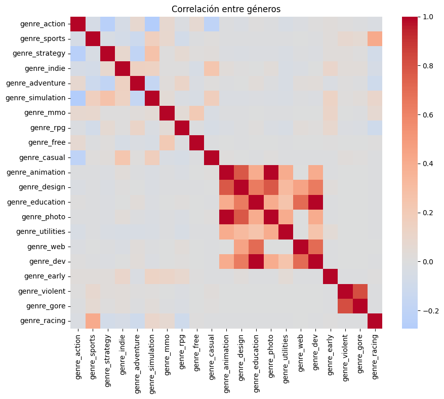

```python
# Correlaciones
valid_genres = games_eda[genre_cols].columns[games_eda[genre_cols].sum() > 0] # Género en al menos un juego

genre_corr = games_eda[valid_genres].corr()

plt.figure(figsize=(10, 8))
sns.heatmap(genre_corr, cmap="coolwarm", center=0, square=True)
plt.title("Correlación entre géneros")
plt.show()
```

```python
# Generos con correlaciones por encima de 0.4
strong_corr = (
    genre_corr.where(np.triu(np.ones(genre_corr.shape), k=1).astype(bool))  # Duplicados
    .stack()                                                                # Formato largo (col1, col2, valor)
    .reset_index()
    .rename(columns={0: "correlation"})
    .query("correlation > 0.4")                                             # Solo correlacione altas
    .sort_values("level_0", ascending=False)
)

print("Correlaciones entre géneros > 0.4:\n")
strong_corr.round(2)
```

```
Correlaciones entre géneros > 0.4:
```

|  | level_0 | level_1 | correlation |
| --- | --- | --- | --- |
| 195 | genre_web | genre_dev | 0.71 |
| 207 | genre_violent | genre_gore | 0.82 |
| 38 | genre_sports | genre_racing | 0.41 |
| 182 | genre_photo | genre_utilities | 0.41 |
| 184 | genre_photo | genre_dev | 0.41 |
| 174 | genre_education | genre_photo | 0.41 |
| 176 | genre_education | genre_web | 0.71 |
| 177 | genre_education | genre_dev | 1.00 |
| 165 | genre_design | genre_education | 0.63 |
| 166 | genre_design | genre_photo | 0.77 |
| 169 | genre_design | genre_dev | 0.63 |
| 168 | genre_design | genre_web | 0.45 |
| 157 | genre_animation | genre_photo | 1.00 |
| 158 | genre_animation | genre_utilities | 0.41 |
| 160 | genre_animation | genre_dev | 0.41 |
| 155 | genre_animation | genre_design | 0.77 |
| 156 | genre_animation | genre_education | 0.41 |

```python
# Análisis semántico
genre_names_clean = [g.replace("genre_", "").replace("_", " ") for g in genre_cols] # Listado de géneros sin genre_

# Cargamos el modelo semántico (word embeddings))
nlp = spacy.load("en_core_web_md")

# Calculamos similitud
pairs = []
for i in range(len(genre_names_clean)):
    for j in range(i + 1, len(genre_names_clean)):
        g1, g2 = genre_names_clean[i], genre_names_clean[j]
        sim = nlp(g1).similarity(nlp(g2))
        pairs.append((g1, g2, sim))

# Resultados
semantic_df = (
    pd.DataFrame(pairs, columns=["genre_1", "genre_2", "similarity"])
    .assign(pair=lambda df: df.apply(lambda r: tuple(sorted([r["genre_1"], r["genre_2"]])), axis=1))
    .drop_duplicates("pair")
    .drop(columns="pair")
    .sort_values("similarity", ascending=False)
)
semantic_df.sort_values("similarity", ascending=False).round(2)
```

|  | genre_1 | genre_2 | similarity |
| --- | --- | --- | --- |
| 484 | nudity | gore | 1.00 |
| 177 | mmo | rpg | 1.00 |
| 474 | sexual | violent | 0.64 |
| 389 | photo | tutorial | 0.61 |
| 76 | strategy | training | 0.57 |
| ... | ... | ... | ... |
| 373 | education | 360 | -0.06 |
| 125 | adventure | free | -0.06 |
| 516 | doc | 360 | -0.07 |
| 471 | early | 360 | -0.09 |
| 406 | training | 360 | -0.10 |

528 rows × 3 columns

```python
# Embeddings de cada palabra
embeddings = np.array([nlp(g).vector for g in genre_names_clean])

# Clustering jerárquico
clustering = AgglomerativeClustering(n_clusters=6, metric='euclidean', linkage='ward')
labels = clustering.fit_predict(embeddings)

semantic_clusters = pd.DataFrame({
    "genre": genre_names_clean,
    "cluster": labels
}).sort_values("cluster")
```

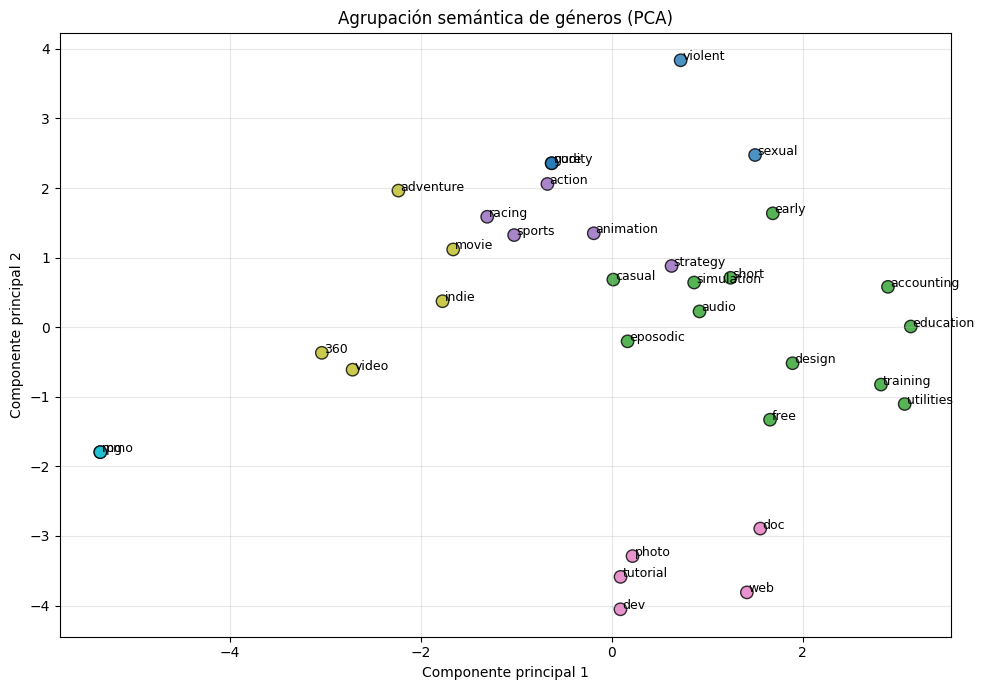

```python
# Reducimos los embeddings
pca = PCA(n_components=2)
embeddings_2d = pca.fit_transform(embeddings)

# df con resultados
plot_df = pd.DataFrame({
    "genre": genre_names_clean,
    "x": embeddings_2d[:, 0],
    "y": embeddings_2d[:, 1],
    "cluster": labels
})

# Plot
plt.figure(figsize=(10, 7))
scatter = plt.scatter(
    plot_df["x"], plot_df["y"],
    c=plot_df["cluster"], cmap="tab10", s=80, alpha=0.8, edgecolor="k"
)

plt.title("Agrupación semántica de géneros (PCA)")
plt.xlabel("Componente principal 1")
plt.ylabel("Componente principal 2")

# Etiquetas
for _, row in plot_df.iterrows():
    plt.text(row["x"] + 0.02, row["y"], row["genre"], fontsize=9)

plt.grid(alpha=0.3)
plt.tight_layout()
plt.show()
```

# 📜 Análisis variables de texto

En este bloque vamos a tratar el análisis de la información textual. Los objetivos son evaluar la caldad y completitud de los textos asi como explorar la estructura semántica del corpus.

## Preparación de la variable genres

El objetivo es convertirlas variables de género en una representación textual unificada y semánticamente enriwuecida. Para ello vamos a crer un diccionario con las descripciones extraidas de Steam y crear una nueva columna, **genres_total** que incluya toda la información de aquellos géneros a los que pertenece un juego.

```python
# Diccionario de descripciones de cada genre.
genre_descriptions = {
    "360": "Games offering immersive 360-degree video experiences, allowing players to explore environments from every angle beyond traditional 2D displays.",
    "accounting": "Games related to accounting or financial management, often used for educational or simulation purposes within business contexts.",
    "action": "Fast-paced games involving quick reflexes, real-time decision making, and dynamic environments. Includes shooters, platformers, and fighting games.",
    "adventure": "Games centered on exploration, storytelling, and puzzle-solving. Often narrative-driven with engaging characters and immersive worlds.",
    "animation": "Games focusing on 3D modeling, rigging, texturing, animation, and visual effects — appealing to artists and designers in the digital arts field.",
    "audio": "Titles oriented toward music or sound creation, including digital audio workstations, sound design, and music composition tools.",
    "casual": "Relaxed and accessible games designed for short, stress-free sessions. Common examples include puzzles, hidden-object, and time management games.",
    "design": "Games emphasizing visual creativity, art, or world-building. Includes illustration, visual novels, and aesthetically-driven experiences.",
    "dev": "Games or tools focused on the process of video game development — programming, design, art, sound, and testing — often educational or creative in nature.",
    "doc": "Documentary-style games depicting real events, people, or historical phenomena through interactive or narrative means.",
    "early": "Early Access games available before official release, allowing players to experience and influence development while features are still being built.",
    "education": "Educational games that teach concepts, skills, or subjects interactively — ranging from academic simulations to training tools.",
    "eposodic": "Games released in chapters or installments, each continuing the main story or gameplay experience over time.",
    "free": "Free-to-play games that can be downloaded and played at no cost, sometimes offering in-game purchases for additional content or features.",
    "indie": "Independently developed games emphasizing creativity, innovation, and unique artistic vision outside mainstream publishing models.",
    "mmo": "Massively Multiplayer Online games featuring persistent worlds, social interaction, and cooperative or competitive large-scale gameplay.",
    "movie": "Games based on or inspired by movies — adaptations, spin-offs, or cinematic homages combining storytelling and gameplay.",
    "photo": "Photo editing or photography-related games featuring image manipulation tools, filters, and creative digital art mechanics.",
    "racing": "Racing games simulating motor sports — from go-karts to Formula 1 — emphasizing speed, skill, and vehicle management.",
    "rpg": "Role-playing games where players assume character roles, develop abilities, and experience story-driven worlds through exploration and choice.",
    "sexual": "Games featuring explicit sexual content, themes, or imagery intended for mature audiences.",
    "short": "Short-form games designed to be completed in a few hours, providing quick, focused experiences.",
    "simulation": "Games replicating real-world systems or activities — from city-building and business management to flight and life simulations.",
    "sports": "Sports simulations and games that recreate physical sports such as football, basketball, or tennis in a digital environment.",
    "strategy": "Games requiring critical thinking, planning, and resource management. Includes RTS, TBS, and grand strategy subgenres.",
    "training": "Games or simulators aimed at practicing specific skills, often in professional or educational contexts.",
    "tutorial": "Games that include instructional or guided content to teach mechanics or gameplay basics to new players.",
    "utilities": "Utility applications related to gaming, such as optimization tools, performance monitors, or library managers.",
    "video": "Games focused on video production — editing, directing, or animating film-like content within interactive environments.",
    "web": "Games or tools related to web publishing, coding, or digital design — often educational and creative simulations.",
    "gore": "Games featuring graphic depictions of blood, dismemberment, and explicit violence, with realistic portrayals of injury and death that some players may find disturbing.",
    "violent":"Games containing intense or graphic depictions of violence, including aggressive combat, bloodshed, and other violent acts that may be unsuitable for children or sensitive audiences.",
    "nudity": "Games featuring partial or full nudity, ranging from non-sexual or artistic depictions to explicit sexual content, clearly marked so players can filter mature-rated experiences."
}
```

```python
# Juntar géneros true de cada juego con la descripción
def combine_genres_with_descriptions(row):
    texts = []
    for col in genre_cols:       # Recorremos todas las columnas de géneros
        if row[col] == 1:        # Si el juego pertenece a ese género
            genre_name = col.replace("genre_", "")  # Quitamos el prefijo 'genre_'

            # Si el género está en el diccionario, añadimos genre_name + descripción
            if genre_name in genre_descriptions:
                desc = genre_descriptions[genre_name]
                texts.append(f'{genre_name}: {desc}')

            # Si no hay descripción, al menos añadimos el nombre del género
            else:
                texts.append(genre_name)

    # Unimos todos los textos en un único string
    # Si no hay géneros marcados, devolvemos cadena vacía
    return " ".join(texts) if texts else ""

# Aplicamos
games_eda["genres_total"] = games_eda.apply(combine_genres_with_descriptions, axis=1)

# Ejemplo
games_eda[games_eda["name"] == "METAL GEAR SURVIVE"]
```

|  | appid | name | positive_reviews | total_reviews | score_reviews | free | description | average_forever | median_forever | developers | ... | genre_movie | genre_doc | genre_eposodic | genre_short | genre_tutorial | genre_360 | genre_racing | release_year | developer_level | genres_total |
| --- | --- | --- | --- | --- | --- | --- | --- | --- | --- | --- | --- | --- | --- | --- | --- | --- | --- | --- | --- | --- | --- |
| 932 | 543900 | METAL GEAR SURVIVE | 2343.0 | 3634.0 | 0.644744 | 0.0 | METAL GEAR SURVIVE builds upon METAL GEAR SOLI... | None | None | KONAMI | ... | 0.0 | 0.0 | 0.0 | 0.0 | 0.0 | 0.0 | 0.0 | 2018.0 | small | action: Fast-paced games involving quick refle... |

1 rows × 56 columns

## Limpieza y preprocesamiento

El proceso de limpieza busca eliminar ruido, homogeneizar el formato y preparar el contenido para la posterior vectorización. Se construye primero text_full concatenando las tres columnas textuales (description, content_descriptors_notes, genres_total) y luego se aplica la misma función de limpieza a las cuatro columnas (description_clean, content_clean, genres_clean, text_full_clean).

```python
# Función para limpiar. Usamos BeautifulSoup porque hay etiquetas HTML
def clean_text(text):
    if pd.isna(text):
        return ""

    text = BeautifulSoup(text, "html.parser").get_text(separator=" ")  # Etiquetas HTML
    text = re.sub(r"http\S+", " ", text)         # URLs
    text = text.lower()                          # Minúsculas
    text = re.sub(r"[^\w\s]", " ", text)         # Letras y números
    text = re.sub(r"\s+", " ", text).strip()     # Espacios extra

    # Lematizar manteniendo negaciones
    doc = nlp(text)
    lemmas = [token.lemma_ for token in doc if not token.is_stop or token.text in ["no", "not"]]
    text = " ".join(lemmas)

    return text

# Columna con el texto total
games_eda["text_full"] = (
    games_eda["description"].fillna("") + " " +
    games_eda["content_descriptors_notes"].fillna("") + " " +
    games_eda["genres_total"].fillna("")
).str.strip()

# Aplicamos la limpieza a las 4 columnas
games_eda["description_clean"] = games_eda["description"].apply(clean_text)
games_eda["content_clean"]     = games_eda["content_descriptors_notes"].apply(clean_text)
games_eda["genres_clean"]      = games_eda["genres_total"].apply(clean_text)
games_eda["text_full_clean"]   = games_eda["text_full"].apply(clean_text)
```

## Análisis descriptivo e idioma

En este apartado vamos a evaluar la calidad y consistencia del texto obtenido tras la limpieza.

```python
# Detectamos el idioma
def safe_detect_lang(txt):
    try:
        return detect(txt) if txt else "unknown"
    except:
        return "unknown"

games_eda["lang_detected"] = games_eda["text_full_clean"].apply(safe_detect_lang)

print("\nIdiomas detectados:")
print(games_eda["lang_detected"].value_counts())
print(games_eda["lang_detected"].value_counts(normalize=True).mul(100).round(1))
```

```
Idiomas detectados:
lang_detected
en         2475
unknown      71
ja            9
zh-cn         5
ru            5
no            5
pt            2
tr            1
ko            1
vi            1
es            1
Name: count, dtype: int64
lang_detected
en         96.1
unknown     2.8
ja          0.3
zh-cn       0.2
ru          0.2
no          0.2
pt          0.1
tr          0.0
ko          0.0
vi          0.0
es          0.0
Name: proportion, dtype: float64
```

```python
# Solo descripciones en inglés
games_eda = games_eda[
    games_eda["lang_detected"].isin(["en"])
].copy()

# Resultados
print("\nJuegos finales (solo inglés)", games_eda.shape)
print(games_eda["lang_detected"].value_counts(normalize=True).mul(100).round(1))
```

```
Juegos finales (solo inglés) (2475, 62)
lang_detected
en    100.0
Name: proportion, dtype: float64
```

```python
# Comrpobar nulos
empty_pct = pd.Series({
    "description_clean": (games_eda["description_clean"] == "").mean()*100,
    "content_clean":     (games_eda["content_clean"]     == "").mean()*100,
    "genres_clean":      (games_eda["genres_clean"]      == "").mean()*100,
    "text_full_clean":   (games_eda["text_full_clean"]   == "").mean()*100,
}).round(2)
print("% de vacíos por columna (tras limpieza):\n", empty_pct.to_string())
```

```
% de vacíos por columna (tras limpieza):
 description_clean     0.36
content_clean        75.15
genres_clean          0.24
text_full_clean       0.00
```

```python
# Comprobar longitud
for col in ["description_clean","content_clean","genres_clean","text_full_clean"]:
    games_eda[f"{col}_len"] = games_eda[col].str.len()

desc_stats = games_eda[["description_clean_len","content_clean_len","genres_clean_len","text_full_clean_len"]].describe(percentiles=[.25,.5,.75,.9]).round(1)
print("\nNúmero de caracteres:\n", desc_stats.to_string())
```

```
Número de caracteres:
        description_clean_len  content_clean_len  genres_clean_len  text_full_clean_len
count                 2475.0             2475.0            2475.0               2475.0
mean                  1272.8               29.3             317.6               1620.9
std                    898.5               70.5             154.6                926.9
min                      0.0                0.0               0.0                145.0
25%                    691.5                0.0             231.0               1021.5
50%                   1071.0                0.0             333.0               1435.0
75%                   1615.0                0.0             380.0               2000.0
90%                   2287.8              112.0             490.6               2689.4
max                   9608.0              817.0            1156.0               9846.0
```

## Análisis del vocabulario

Este apartado tiene como objetivo explorar el contenido léxico del corpus (tras la limpieza) con el fin de identificar términos dominantes, su distribución y su potencial valor informativo para los modelos semánticos.

```python
# Frecuencia de palabras más comunes
text_cols_clean = ["description_clean", "content_clean", "genres_clean"]

# Palabras más frecuentes
def top_terms(series, label, n=15):
    vec = CountVectorizer(stop_words=stop_words, max_features=n)
    X = vec.fit_transform(series.fillna(""))
    counts = X.toarray().sum(axis=0)
    vocab = vec.get_feature_names_out()
    freq_df = (
        pd.DataFrame({"term": vocab, "count": counts})
        .sort_values("count", ascending=False)
        .reset_index(drop=True)
    )
    print(f"\nPalabras más frecuentes en {label}:\n")
    display(freq_df)
    return freq_df

# Sacamos las palabras ma´s frecuentes de cada columna
top_desc   = top_terms(games_eda["description_clean"], "description_clean")
top_notes  = top_terms(games_eda["content_clean"], "content_clean")
top_genres = top_terms(games_eda["genres_clean"], "genres_clean")
```

```
Palabras más frecuentes en description_clean:
```

|  | term | count |
| --- | --- | --- |
| 0 | game | 6984 |
| 1 | new | 4721 |
| 2 | world | 3550 |
| 3 | player | 2602 |
| 4 | play | 2321 |
| 5 | feature | 2088 |
| 6 | experience | 1878 |
| 7 | time | 1853 |
| 8 | character | 1852 |
| 9 | story | 1747 |
| 10 | unique | 1723 |
| 11 | mode | 1712 |
| 12 | include | 1631 |
| 13 | battle | 1568 |
| 14 | build | 1494 |

```
Palabras más frecuentes en content_clean:
```

|  | term | count |
| --- | --- | --- |
| 0 | game | 447 |
| 1 | violence | 376 |
| 2 | contain | 314 |
| 3 | content | 296 |
| 4 | blood | 221 |
| 5 | gore | 187 |
| 6 | sexual | 187 |
| 7 | appropriate | 177 |
| 8 | character | 149 |
| 9 | language | 144 |
| 10 | age | 141 |
| 11 | nudity | 124 |
| 12 | mature | 113 |
| 13 | player | 108 |
| 14 | include | 107 |

```
Palabras más frecuentes en genres_clean:
```

|  | term | count |
| --- | --- | --- |
| 0 | game | 8489 |
| 1 | world | 2562 |
| 2 | include | 2337 |
| 3 | develop | 2109 |
| 4 | real | 1915 |
| 5 | management | 1860 |
| 6 | drive | 1825 |
| 7 | character | 1820 |
| 8 | exploration | 1820 |
| 9 | time | 1755 |
| 10 | puzzle | 1619 |
| 11 | emphasize | 1484 |
| 12 | simulation | 1449 |
| 13 | role | 1438 |
| 14 | creativity | 1395 |

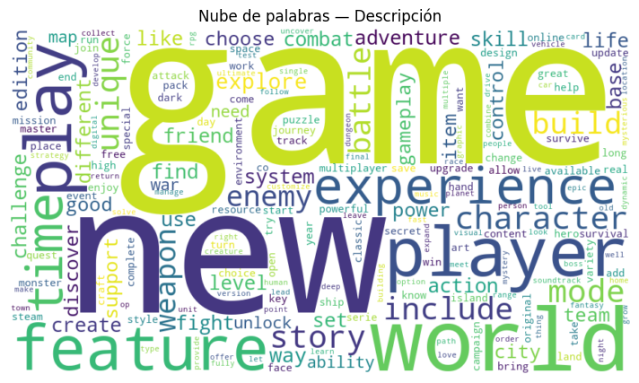

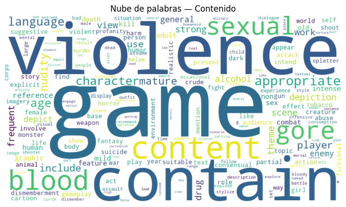

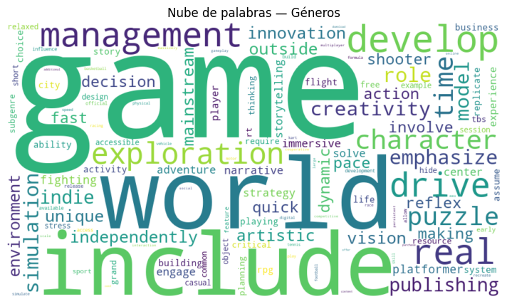

```python
def make_wordcloud(series, title):
    text = " ".join(series.dropna())
    wc = WordCloud(width=900, height=500, background_color="white",
                   stopwords=set(stop_words), collocations=False).generate(text)
    plt.figure(figsize=(10,5))
    plt.imshow(wc, interpolation="bilinear")
    plt.axis("off")
    plt.title(title)
    plt.show()

# Nubes por fuente textual
make_wordcloud(games_eda["description_clean"], "Nube de palabras — Descripción")
make_wordcloud(games_eda["content_clean"], "Nube de palabras — Contenido")
make_wordcloud(games_eda["genres_clean"], "Nube de palabras — Géneros")
```

## Vectorización TF-IDF

El objetivo es tener una primera visualización de la riqueza, distribución y estructura del texto.

```python
# Creamos el vectorizador
tfidf = TfidfVectorizer(
    max_features=5000,      # Seleccionar las 5000 palabras o bigramas más importantes
    stop_words="english",   # Eliminar términos funcionales
    ngram_range=(1, 2),     # Incluir unigramas y bigramas
    min_df=3                # Términos que aparecen en al menos 3 documentos
)

# Ajustar y transformar
X_tfidf = tfidf.fit_transform(games_eda["text_full_clean"].fillna(""))

print(f"Matriz TF-IDF creada correctamente.")
print(f"Dimensiones: {X_tfidf.shape[0]} juegos × {X_tfidf.shape[1]} términos")
```

```
Matriz TF-IDF creada correctamente.
Dimensiones: 2475 juegos × 5000 términos
```

```python
# Palabras más distintivas
idf_df = pd.DataFrame({
    "term": tfidf.get_feature_names_out(),
    "idf": tfidf.idf_
}).sort_values("idf", ascending=False)

print("Palabras más distintivas (mayor IDF):")
display(idf_df.round(3).head(20))

print("Palabras más comunes (menor IDF):")
display(idf_df.round(3).tail(20))
```

```
Palabras más distintivas (mayor IDF):
```

|  | term | idf |
| --- | --- | --- |
| 4994 | zack | 7.428 |
| 4081 | sniper ghost | 7.428 |
| 2910 | myst | 7.428 |
| 1074 | dead daylight | 7.428 |
| 2074 | gundam | 7.428 |
| 3813 | rufus | 7.428 |
| 4120 | south park | 7.428 |
| 3957 | shadowrun | 7.428 |
| 4201 | star trek | 7.428 |
| 3883 | scp | 7.428 |
| 3259 | pga | 7.428 |
| 2243 | icarus | 7.428 |
| 222 | anno | 7.428 |
| 2616 | long dark | 7.428 |
| 4740 | vault tec | 7.428 |
| 1980 | ghost warrior | 7.428 |
| 3610 | receiver | 7.428 |
| 2465 | killing floor | 7.428 |
| 3790 | romance kingdom | 7.428 |
| 2871 | motogp | 7.428 |

```
Palabras más comunes (menor IDF):
```

|  | term | idf |
| --- | --- | --- |
| 120 | action | 1.559 |
| 4790 | vision | 1.552 |
| 3518 | puzzle | 1.552 |
| 1427 | emphasize | 1.536 |
| 2839 | model | 1.528 |
| 1482 | environment | 1.521 |
| 1572 | exploration | 1.520 |
| 1655 | feature | 1.517 |
| 2950 | new | 1.501 |
| 3330 | player | 1.471 |
| 1320 | drive | 1.467 |
| 1550 | experience | 1.467 |
| 661 | character | 1.380 |
| 1173 | develop | 1.318 |
| 4644 | unique | 1.315 |
| 3591 | real | 1.306 |
| 4481 | time | 1.215 |
| 4939 | world | 1.159 |
| 2289 | include | 1.144 |
| 1850 | game | 1.001 |

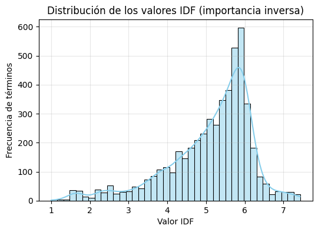

```python
# Distribución IDF
plt.figure(figsize=(6,4))
sns.histplot(idf_df["idf"], bins=40, color="skyblue", kde=True)
plt.title("Distribución de los valores IDF (importancia inversa)")
plt.xlabel("Valor IDF")
plt.ylabel("Frecuencia de términos")
plt.grid(alpha=0.3)
plt.show()
```

```python
# Dispersión del texto
non_zero = X_tfidf.nnz
total = X_tfidf.shape[0] * X_tfidf.shape[1]
sparsity = 1 - (non_zero / total)
print(f"Dispersión de la matriz TF-IDF: {sparsity*100:.2f}% de ceros")
```

```
Dispersión de la matriz TF-IDF: 96.25% de ceros
```

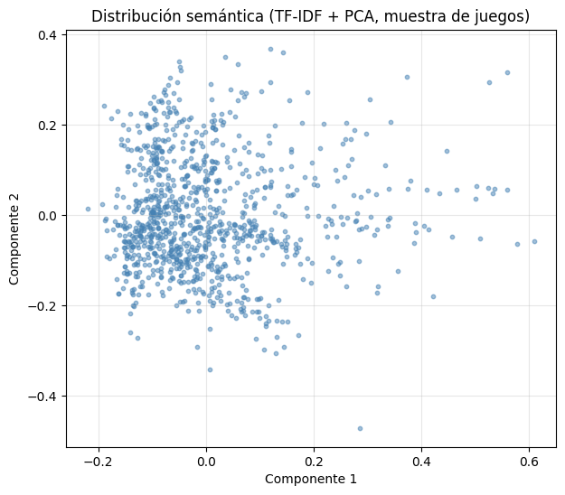

```python
# Exploración semántica (PCA)
# Convertimos a matriz densa solo para visualización (puede tardar si hay muchos juegos)
sample_size = min(1000, X_tfidf.shape[0])  # muestra por seguridad
pca = PCA(n_components=2, random_state=42)
X_pca = pca.fit_transform(X_tfidf[:sample_size].toarray())

plt.figure(figsize=(7,6))
plt.scatter(X_pca[:,0], X_pca[:,1], alpha=0.5, s=10, color="steelblue")
plt.title("Distribución semántica (TF-IDF + PCA, muestra de juegos)")
plt.xlabel("Componente 1")
plt.ylabel("Componente 2")
plt.grid(alpha=0.3)
plt.show()
```

# 💾 Guardado de la información final

```python
conn = sqlite3.connect(db_path)
cur = conn.cursor()

games_eda.to_sql("games_eda", conn, if_exists="replace", index=False)

conn.close()
```

```python
# Número de filas guardadas
print(f"Número de filas guardadas en la tabla 'games_eda': {len(games_eda):,}")
# Columnas guardadas
print(f"Columnas guardadas en la tabla 'games_eda': {', '.join(games_eda.columns)}")
```

```
Número de filas guardadas en la tabla 'games_eda': 2,475
Columnas guardadas en la tabla 'games_eda': appid, name, positive_reviews, total_reviews, score_reviews, free, description, average_forever, median_forever, developers, publishers, windows, mac, linux, release_date, content_descriptors_notes, multijugador, cooperativo, competitivo, multidispositivo,…
```